# **CSHS Webinar** Introduction to Spatial Vector Data Analysis in R Examples

R.D. (Dan) Moore

2020-December-01

# Load libraries

```r
library(dplyr)
library(sf)
library(magrittr)
library(tidyr)
library(ggplot2)
library(knitr)
library(ggspatial)
library(here)
library(raster)
library(bcmaps)
library(rnaturalearth)
library(rgeos)
library(bcmapsdata)
```

```r
# options for plots
theme_set(theme_bw())
my_blue <- rgb(0.2, 0.2, 1.0, alpha = 0.2)
```

# How to run these examples

To run these examples, follow these steps:

1. Ensure that you have all of the required packages installed. To install a package, you can execute `install.packages(`**package_name**`)` via the console.
2. Note that you will need to download the **bcmapsdata** package from GitHub. You can do this by executing `install.packages('bcmapsdata', repos = 'https://bcgov.github.io/drat/')` at the console.
3. The Biogeoclimatic Ecological Zone data can be manually downloaded via
- https://catalogue.data.gov.bc.ca/dataset/bec-map/resource/46ceb84a-3f6d-436c-b4c1-c89beb72d11a#edc-pow

Alternatively, they can be accessed via the following code, which also stores the data on the local hard drive as an RDA file:

```r
# bec_fn is the name of file into which the data will be saved, for example:
#    bec_fn <- "c:/Data/bec.rda"
bec_sf <- bec(class = "sf")
save(bec_sf, file = bec_fn)
```

Note: the **bcmaps** package must be installed and loaded to run the `bec()` function.

4. Create a folder on your hard drive for this project. It could be named, for example,`c:/cshs/spatial_vector`.
5. Open RStudio and click on **File … New Project … Existing Directory** and then navigate to the project folder and click on **Create Project**.
6. Within the project folder, create a folder named “data”.
7. Copy the following files into the “data” folder:
- `ec_station_inventory.csv`
- `wsc_fraser_tribs.rda`
- `bec.rda` (see note 3, above, about accessing the data)
- files containing the Fraser River catchment shape files (root name `08MF005_1` and extensions `.shp`, `.shx`, `.prj`, `.qpj` and `shp.xml`).
8. Copy `cshs_web_sf_examples.rmd` into the project folder.
9. Open `cshs_web_sf_examples.rmd` in RStudio. You should be able either to knit the document or to run the code chunks individually by clicking on the green right-pointing triangle in the top right corner of each chunk.

**Note**

If you are unfamiliar with organizing your work within projects and the **here** package, review the links below:

- https://www.tidyverse.org/blog/2017/12/workflow-vs-script/
- https://malco.io/2018/11/05/why-should-i-use-the-here-package-when-i-m-already-using-projects/

# Example 1: Mapping Canadian weather stations by length of record for hourly data

We will generate a **sf** object containing the weather station coordinates and data using the Environment and Climate Change station inventory, which is accessible via

- https://drive.google.com/drive/folders/1WJCDEU34c60IfOnG4rv5EPZ4IhhW9vZH

We will add coastlines and Canada’s borders with the United States by adapting the polygons available from NaturalEarth.

First, we define the Canadian Albers equal-area projection.

```r
# Canadian Albers equal area projection - proj4string
cdn_aea = "+proj=aea +lat_1=50 +lat_2=70 +lat_0=40 +lon_0=-96 +x_0=0 +y_0=0 +ellps=GRS80 +datum=NAD83 +units=m +no_defs"
```

Now we read in the station inventory, compute the number of years of record for hourly data, and then convert to a **sf** object.

```r
ec_fn <- here::here("data", "ec_station_inventory.csv")
ec <- read.csv(ec_fn, skip = 3) %>%
  mutate(stn_name = Name,
         province = Province,
         climate_id = Climate.ID,
         wmo_id = WMO.ID,
         lat = Latitude..Decimal.Degrees.,
         lon = Longitude..Decimal.Degrees.,
         elev = Elevation..m.,
         hly_y1 = HLY.First.Year,
         hly_y2 = HLY.Last.Year,
         dly_y1 = DLY.First.Year,
         dly_y2 = DLY.Last.Year,
         mly_y1 = MLY.First.Year,
         mly_y2 = MLY.Last.Year) %>%
  dplyr::select(stn_name:mly_y2) %>%
  dplyr::filter(lon < -50) %>%
  mutate(dly_ny = dly_y2 - dly_y1,
         hly_ny = hly_y2 - hly_y1)

# create sf object
ec_sf <- st_as_sf(ec, coords = c("lon", "lat"))

# specify crs as longlat
st_crs(ec_sf) <- 4326

# quick look at sf object
head(ec_sf[, 1:10])
```

```
## Simple feature collection with 6 features and 10 fields
## geometry type:  POINT
## dimension:      XY
## bbox:           xmin: -124 ymin: 48.33 xmax: -123.28 ymax: 48.87
## geographic CRS: WGS 84
##                 stn_name         province climate_id wmo_id  elev hly_y1 hly_y2
## 1            ACTIVE PASS BRITISH COLUMBIA    1010066     NA   4.0     NA     NA
## 2            ALBERT HEAD BRITISH COLUMBIA    1010235     NA  17.0     NA     NA
## 3 BAMBERTON OCEAN CEMENT BRITISH COLUMBIA    1010595     NA  85.3     NA     NA
## 4             BEAR CREEK BRITISH COLUMBIA    1010720     NA 350.5     NA     NA
## 5            BEAVER LAKE BRITISH COLUMBIA    1010774     NA  61.0     NA     NA
## 6             BECHER BAY BRITISH COLUMBIA    1010780     NA  12.2     NA     NA
##   dly_y1 dly_y2 mly_y1              geometry
## 1   1984   1996   1984 POINT (-123.28 48.87)
## 2   1971   1995   1971  POINT (-123.48 48.4)
## 3   1961   1980   1961 POINT (-123.52 48.58)
## 4   1910   1971   1910     POINT (-124 48.5)
## 5   1894   1952   1894  POINT (-123.35 48.5)
## 6   1956   1966   1956 POINT (-123.63 48.33)
```

Below, we create the base map layer. The data were read from a server and saved to the local hard drive the first time the script was run, after which the data are read from the local hard drive.

```r
# access NaturalEarth boundary polygons
ne_fn <- here::here("data", "na_ne.rda")
if (file.exists(ne_fn)) {
  load(ne_fn)
} else {
  na_ne <- ne_countries(continent = "north america")
  save(na_ne, file = ne_fn)
}
```

Now convert the data to an **sf** object.

```r
# convert to sf object and take a quick look
na_sf <- st_as_sf(na_ne)
head(na_sf[, 1:10])
```

```
## Simple feature collection with 6 features and 10 fields
## geometry type:  MULTIPOLYGON
## dimension:      XY
## bbox:           xmin: -140.9978 ymin: 8.225028 xmax: -52.6481 ymax: 83.23324
## CRS:            +proj=longlat +datum=WGS84 +no_defs +ellps=WGS84 +towgs84=0,0,0
##    scalerank      featurecla labelrank         sovereignt sov_a3 adm0_dif level
## 17         1 Admin-0 country         4        The Bahamas    BHS        0     2
## 20         1 Admin-0 country         6             Belize    BLZ        0     2
## 27         1 Admin-0 country         2             Canada    CAN        0     2
## 36         1 Admin-0 country         5         Costa Rica    CRI        0     2
## 37         1 Admin-0 country         3               Cuba    CUB        0     2
## 44         1 Admin-0 country         5 Dominican Republic    DOM        0     2
##                 type              admin adm0_a3                       geometry
## 17 Sovereign country        The Bahamas     BHS MULTIPOLYGON (((-77.53466 2...
## 20 Sovereign country             Belize     BLZ MULTIPOLYGON (((-89.14308 1...
## 27 Sovereign country             Canada     CAN MULTIPOLYGON (((-63.6645 46...
## 36 Sovereign country         Costa Rica     CRI MULTIPOLYGON (((-82.96578 8...
## 37 Sovereign country               Cuba     CUB MULTIPOLYGON (((-82.26815 2...
## 44 Sovereign country Dominican Republic     DOM MULTIPOLYGON (((-71.71236 1...
```

Next, extract the geometry, and crop to focus on Canada.

```r
# define bounding box for Canada base map and crop
bb_ca <- c(
  xmin = -180,
  ymin = 40,
  xmax = -10,
  ymax = 85
)
ca_sf <- na_sf %>%
  st_geometry() %>%
  st_crop(bb_ca)
```

```
## although coordinates are longitude/latitude, st_intersection assumes that they are planar
```

Generate a quick plot to check.

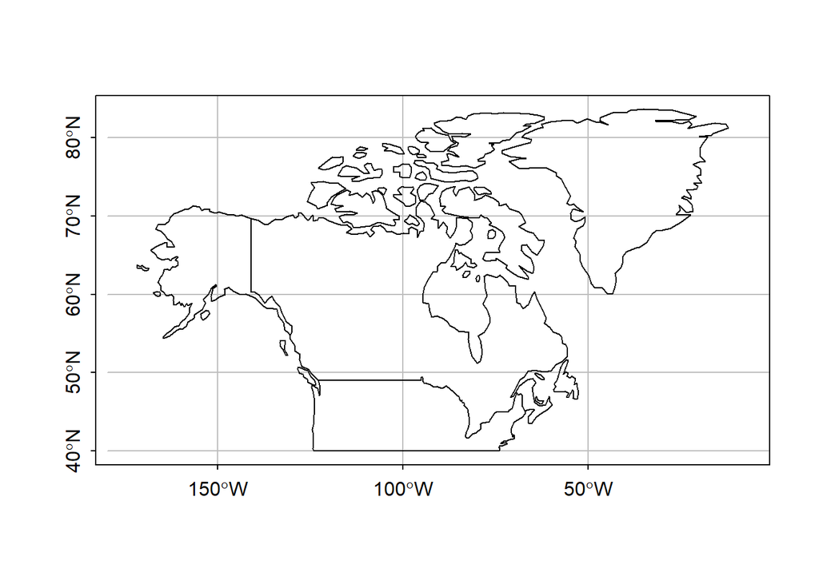

```r
par(tcl = -0.2, mgp = c(2, 0.5, 0))
plot(ca_sf, graticule = TRUE, axes = TRUE)
```

Now we convert the variable representing record length into a set of ordered categories. The `drop_na()` deletes rows with `hly_ny` equal to NA. Otherwise, they would get lumped into the last category.

```r
ec_hly <- ec_sf %>%
  drop_na(hly_ny) %>%
  mutate(hly_class = case_when(
    hly_ny < 11 ~ "1-10 years",
    hly_ny < 21 ~ "11-20 years",
    hly_ny < 31 ~ "21-30 years",
    TRUE ~ ">30 years"
  )) %>%
  mutate(hly_class = factor(hly_class,
                            levels = c("1-10 years", "11-20 years",
                                       "21-30 years", ">30 years")))
head(ec_hly)
```

```
## Simple feature collection with 6 features and 14 fields
## geometry type:  POINT
## dimension:      XY
## bbox:           xmin: -123.72 ymin: 48.42 xmax: -123.23 ymax: 48.82
## geographic CRS: WGS 84
##            stn_name         province climate_id wmo_id   elev hly_y1 hly_y2
## 1  DISCOVERY ISLAND BRITISH COLUMBIA    1012475  71031  18.93   1997   2020
## 2 ESQUIMALT HARBOUR BRITISH COLUMBIA    1012710  71798   3.00   1994   2020
## 3        KELP REEFS BRITISH COLUMBIA    1013998     NA   0.00   1997   2020
## 4           MALAHAT BRITISH COLUMBIA    1014818     NA 275.00   1991   1992
## 5           MALAHAT BRITISH COLUMBIA    1014820  71774 365.80   1994   2020
## 6    NORTH COWICHAN BRITISH COLUMBIA    1015630  71927  44.80   2007   2020
##   dly_y1 dly_y2 mly_y1 mly_y2 dly_ny hly_ny              geometry   hly_class
## 1   1997   2020   1998   2005     23     23 POINT (-123.23 48.42) 21-30 years
## 2   1957   2020   1957   2005     63     26 POINT (-123.44 48.43) 21-30 years
## 3   2018   2020     NA     NA      2     23 POINT (-123.24 48.55) 21-30 years
## 4     NA     NA     NA     NA     NA      1 POINT (-123.58 48.58)  1-10 years
## 5   1920   2020   1920   2005    100     26 POINT (-123.53 48.57) 21-30 years
## 6   2007   2020     NA     NA     13     13 POINT (-123.72 48.82) 11-20 years
```

Finally we plot the map. The first `geom_sf()` function call defines the base layer, and the second adds the points. The `facet_wrap()` function generates a set of maps, one for each category of record length. As mentioned earlier, both **sf** objects use longlat as the CRS, and the `coord_sf()` controls how the map is projected.

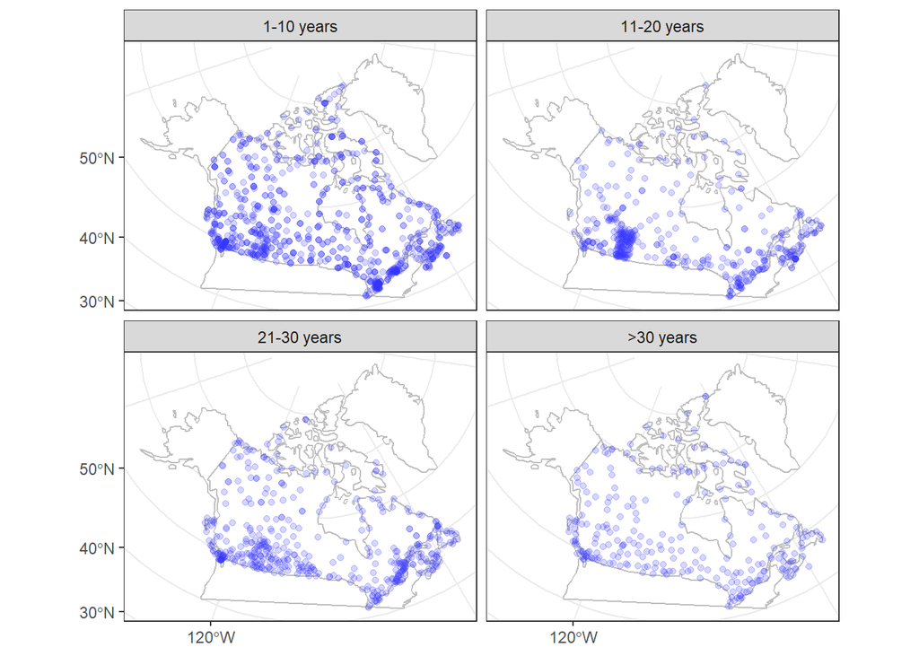

```r
ggplot() +
  geom_sf(data = ca_sf, fill = "white", col = "grey") +
  geom_sf(data = ec_hly, aes(group = hly_class), col = my_blue) +
  facet_wrap(vars(hly_class)) +
  coord_sf(crs = cdn_aea)
```

# Example 2: Finding weather stations that are within or near a catchment boundary

We first read in the shape file for the catchment boundary. Note that the WSC catchment boundaries had been previously downloaded, and the shape files for Fraser River at Hope were stored in the “data” sub-folder for this project.

```r
# Water Survey of Canada station number for Fraser R at Hope
stn_num <- "08MF005"

# get catchment boundary, tranform to BC Albers projection
fr_dsn <- here::here("data", paste0(stn_num,"_1.shp"))
fr <- st_read(dsn = fr_dsn)
fr_albers <- st_transform(fr, crs = 3005)
```

Now we add the buffer and plot the results to check.

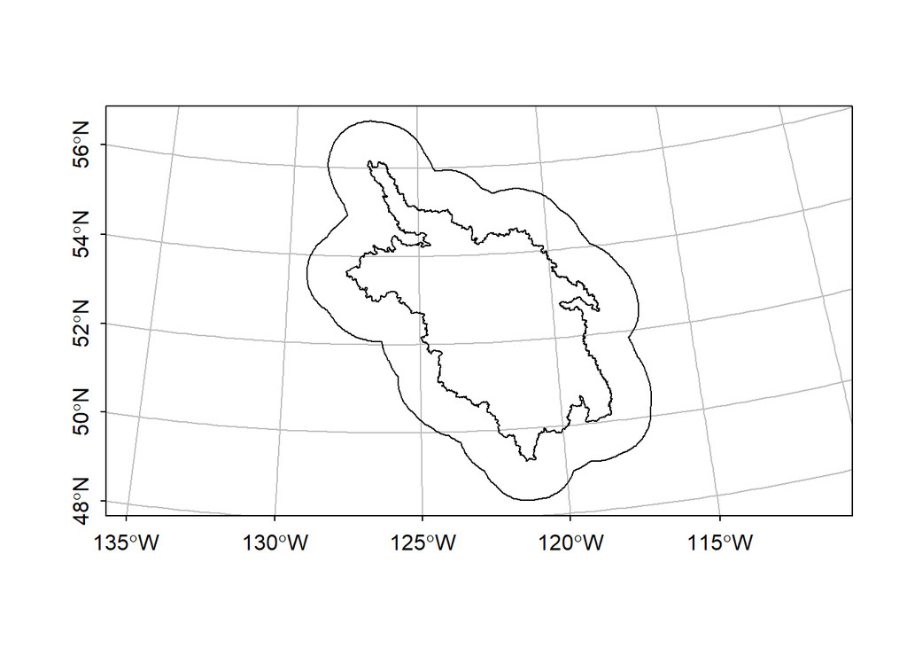

```r
# add 100-km buffer
fr_buffer <- st_buffer(fr_albers, dist = 1e5)
par(tcl = -0.2, mgp = c(2, 0.5, 0))
plot(st_geometry(fr_buffer), graticule = TRUE, axes = TRUE)
plot(st_geometry(fr_albers), add = TRUE)
```

Now we transform the **sf** object containing the Environment Canada station inventory to BC Albers projection.

```r
# get weather station locations, create sf object
ec_albers <- st_transform(ec_sf, crs = st_crs(fr_albers))
```

Generate check plot.

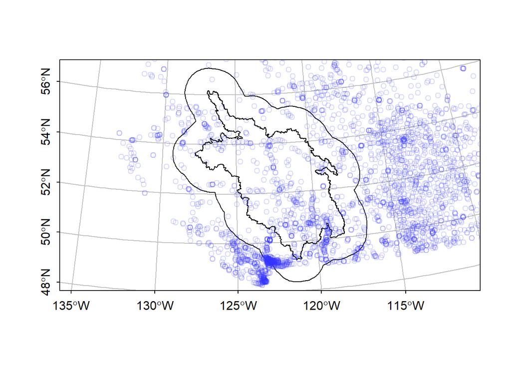

```r
par(tcl = -0.2, mgp = c(2, 0.5, 0))
plot(st_geometry(fr_buffer), graticule = TRUE, axes = TRUE)
plot(st_geometry(fr_albers), add = TRUE)
plot(st_geometry(ec_albers), col = my_blue, add = TRUE)
```

Now we conduct the point-in-polygon search to select the stations within the buffered catchment area.

```r
# perform point-in-polygon search using st_filter()
ec_fr <- st_filter(ec_albers, fr_buffer)

# look at result
head(ec_fr)
```

```
## Simple feature collection with 6 features and 13 fields
## geometry type:  POINT
## dimension:      XY
## bbox:           xmin: 1193940 ymin: 489620.8 xmax: 1217886 ymax: 575164.4
## projected CRS:  NAD83 / BC Albers
##                   stn_name         province climate_id wmo_id   elev hly_y1
## 1                ALTA LAKE BRITISH COLUMBIA    1040390     NA  667.5   1953
## 2  ALTA LAKE NORTHAIR MINE BRITISH COLUMBIA    1040400     NA 1005.8     NA
## 3              ALTA LAKE 2 BRITISH COLUMBIA    1040420     NA  640.1     NA
## 4             ANVIL ISLAND BRITISH COLUMBIA    1040445     NA   30.5     NA
## 5   BOWEN ISLAND CATES BAY BRITISH COLUMBIA    1040911     NA   27.0     NA
## 6 BOWEN ISLAND MILLERS LDG BRITISH COLUMBIA    1040R09     NA   91.1     NA
##   hly_y2 dly_y1 dly_y2 mly_y1 mly_y2 dly_ny hly_ny                 geometry
## 1   1976   1950   1976   1950   1976     26     23 POINT (1217886 575164.4)
## 2     NA   1975   1987   1975   1987     12     NA POINT (1207313 571379.4)
## 3     NA   1931   1969   1931   1969     38     NA POINT (1215744 575072.6)
## 4     NA   1956   1963   1956   1963      7     NA POINT (1195567 504141.7)
## 5     NA   1987   2000   1987   2000     13     NA POINT (1194582 491869.4)
## 6     NA   1972   2001   1972   2001     29     NA POINT (1193940 489620.8)
```

Now we plot the catchment boundary, buffer and points within a map of British Columbia, using the provincial boundary and river network layers from **bcmaps**.

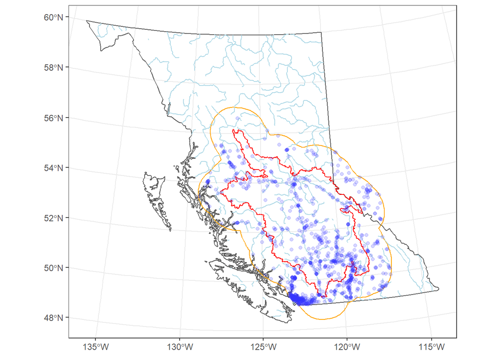

```r
bcb <- bc_bound()
bcw <- watercourses_5M()

ggplot() +
  geom_sf(data = bcb, fill = NA) +
  geom_sf(data = fr_buffer, fill = NA, col = "orange") +
  geom_sf(data = fr_albers, col = "red", fill = NA) +
  geom_sf(data = bcw, col = "lightblue") +
  geom_sf(data = ec_fr, col = my_blue)
```

# Example 3: Determining alpine cover in major tributaries in the Fraser River basin

This example illustrates the use of `st_intersection()` for two sets of polygons. In this specific case, the goal is to determine the fraction of a catchment covered by alpine vegetation.

## Data compilation

### Biogeoclimatic ecological classification zones

The Biogeoclimatic Ecological Classification (BEC) zone system was developed initially for applications in forest management, but has been found to be a powerful tool for characterizing biophysical site characteristics in a broad range of applications. For example, Trubilowicz, Moore, and Buttle (2013) applied it with success to prediction of streamflow regimes for ungauged catchments in British Columbia.

The BEC zone system is hierarchical. The top level are zones, of which there are 16 classes. Within the zones are sub-zones and then variants. We will focus on the zone level of classification.

First, we read in the shape files for the BEC zones. The first time the code is run, it accesses the shape files via `bec()` function in the **bcmaps** package and then stores the data on the local hard drive as a RDA file. The second and subsequent times the code is run, the data are read from the local hard drive.

```r
bec_fn <- here::here("data", "bec.rda")
if (file.exists(bec_fn)) {
  load(bec_fn)
} else {
  bec_sf <- bec(class = "sf")
  save(bec_sf, file = bec_fn)
}
```

### Catchment boundaries

The catchment boundaries can currently be accessed via Government of Canada (2019). In this case, the polygons had been downloaded and were accessed for this exercise from my local hard drive. The first step is to create a vector of the station numbers for some of the tributaries.

```r
# create a vector with station ids for some major tributaries to Fraser River
wsc_fr <- c("08kc001", "08jc002", "08kg001", "08kh006", "08ke016",
            "08me002", "08mf065", "08lf051") %>% toupper()
```

The first time the next code chunk is run, it reads in the polygons for selected WSC stations on some major tributaries to Fraser River as individual layers and stores them in a list. These are then assembled into a **sf** object and then saved as an RDA file. After the first time the code chunk is run, the code loads the data as an RDA file.

A caveat regarding the code chunk below is that I have had no previous experience with GDB files, and was unable to figure out how to read more than one layer at a time. The code below works, but there is probably a more elegant way to compile multiple layers into a **sf** object.

```r
# read in the WSC polygons
wsc_fn <- here::here("data", "wsc_fraser_tribs.rda")
if (file.exists(wsc_fn)) {
  load(wsc_fn)
} else {
  fr_polygons <- list()
  wsc_gdb <- "C:/Data/wsc_polygons_2020Nov29/WSC_Basins.gdb"
  for (i in 1:length(wsc_fr)) {
    fr_polygons[[i]] <- st_read(wsc_gdb,
                        layer = paste0("EC_", wsc_fr[i], "_1"))
  }
  frpoly_sf <- st_as_sf(fr_polygons[[1]])
  for (i in 2:length(wsc_fr)) {
    frpoly_sf <- rbind(frpoly_sf, fr_polygons[[i]])
  }
  save(frpoly_sf, file = wsc_fn)
}
```

Prior to analysis, we project the polygons to BC Albers projection for consistency with the BEC data set.

```r
frpoly_albers <- frpoly_sf %>% st_transform(crs = 3005)
wsc_stns <- frpoly_albers %>%
  st_set_geometry(NULL) %>%
  dplyr::select(Station, stn_name = StationNam, basin_area = Shape_Area)
knitr::kable(wsc_stns)
```

| Station | stn_name | basin_area |
| --- | --- | --- |
| 08KC001 | SALMON RIVER NEAR PRINCE GEORGE | 4232666528 |
| 08JC002 | NECHAKO RIVER AT ISLE PIERRE | 42747308741 |
| 08KG001 | WEST ROAD RIVER NEAR CINEMA | 12429804451 |
| 08KH006 | QUESNEL RIVER NEAR QUESNEL | 11546813480 |
| 08KE016 | BAKER CREEK AT QUESNEL | 1554579561 |
| 08ME002 | CAYOOSH CREEK NEAR LILLOOET | 885228829 |
| 08MF065 | NAHATLATCH RIVER BELOW TACHEWANA CREEK | 712150216 |
| 08LF051 | THOMPSON RIVER NEAR SPENCES BRIDGE | 55417272407 |

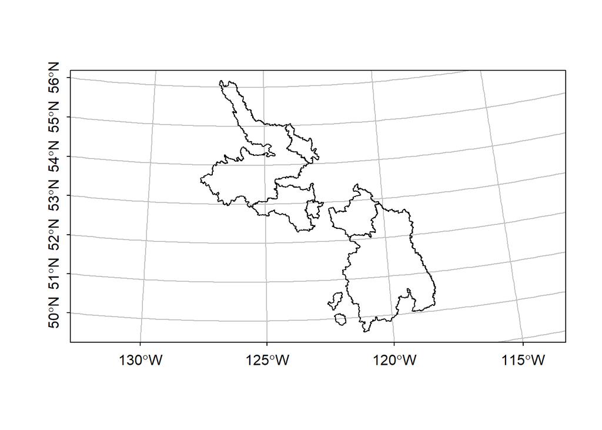

```r
par(tcl = -0.2, mgp = c(2, 0.5, 0))
plot(st_geometry(frpoly_albers), graticule = TRUE, axes = TRUE)
```

## Analysis

Within the BEC zone system, three classes represent alpine cover: CMA (Coast Mountain-heather Alpine), IMA (Interior Mountain-heather Alpine), and Boreal Altai Fescue Alpine (BAFA).

First, apply a filter to retain only the BEC zones representing alpine cover.

```r
alpine <- bec_sf %>%
  dplyr::filter(ZONE %in% c("IMA", "CMA", "BAFA"))
head(alpine)
```

```
## Simple feature collection with 6 features and 20 fields
## geometry type:  POLYGON
## dimension:      XY
## bbox:           xmin: 1171217 ymin: 662896.1 xmax: 1190959 ymax: 679914.1
## projected CRS:  NAD83 / BC Albers
## # A tibble: 6 x 21
##   id    FEATURE_CLASS_S~ ZONE  SUBZONE VARIANT PHASE NATURAL_DISTURB~ MAP_LABEL
##   <chr>            <int> <chr> <chr>   <chr>   <chr> <chr>            <chr>
## 1 WHSE~              435 BAFA  un      <NA>    <NA>  NDT5             BAFAun
## 2 WHSE~              435 BAFA  un      <NA>    <NA>  NDT5             BAFAun
## 3 WHSE~              435 BAFA  un      <NA>    <NA>  NDT5             BAFAun
## 4 WHSE~              435 BAFA  un      <NA>    <NA>  NDT5             BAFAun
## 5 WHSE~              435 BAFA  un      <NA>    <NA>  NDT5             BAFAun
## 6 WHSE~              435 BAFA  un      <NA>    <NA>  NDT5             BAFAun
## # ... with 13 more variables: BGC_LABEL <chr>, ZONE_NAME <chr>,
## #   SUBZONE_NAME <chr>, VARIANT_NAME <chr>, PHASE_NAME <chr>,
## #   NATURAL_DISTURBANCE_NAME <chr>, FEATURE_AREA_SQM <dbl>,
## #   FEATURE_LENGTH_M <dbl>, FEATURE_AREA <dbl>, FEATURE_LENGTH <int>,
## #   OBJECTID <int>, SE_ANNO_CAD_DATA <chr>, geometry <POLYGON [m]>
```

Now generate a map with the British Columbia border and catchment boundaries overlaid.

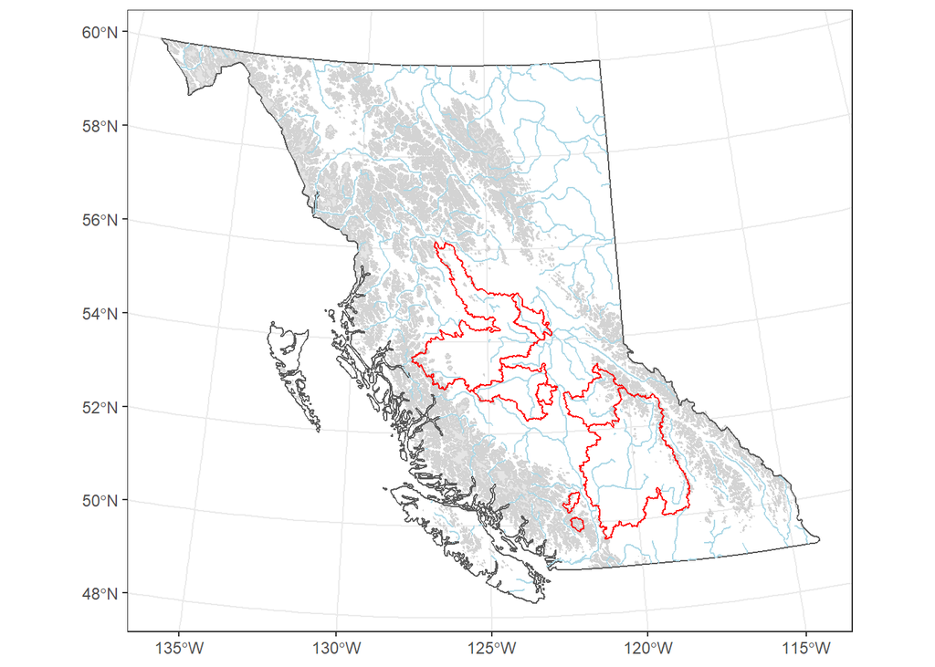

```r
ggplot() +
  geom_sf(data = alpine, col = "lightgrey") +
  geom_sf(data = bcb, fill = NA) +
  geom_sf(data = bcw, col = "lightblue") +
  geom_sf(data = frpoly_albers, fill = NA, col = "red")
```

Next, intersect the catchment and alpine cover polygons.

```r
wsc_alp_int <- st_intersection(frpoly_albers, alpine)
head(wsc_alp_int)
```

```
## Simple feature collection with 6 features and 27 fields
## geometry type:  GEOMETRY
## dimension:      XY
## bbox:           xmin: 1042149 ymin: 854772.3 xmax: 1078854 ymax: 869760.9
## projected CRS:  NAD83 / BC Albers
##     Station                  StationNam   Stn_UID Shp_Area Shp_Perime
## 3   08KG001 WEST ROAD RIVER NEAR CINEMA 08KG001_1  12429.8    906.499
## 3.1 08KG001 WEST ROAD RIVER NEAR CINEMA 08KG001_1  12429.8    906.499
## 3.2 08KG001 WEST ROAD RIVER NEAR CINEMA 08KG001_1  12429.8    906.499
## 3.3 08KG001 WEST ROAD RIVER NEAR CINEMA 08KG001_1  12429.8    906.499
## 3.4 08KG001 WEST ROAD RIVER NEAR CINEMA 08KG001_1  12429.8    906.499
## 3.5 08KG001 WEST ROAD RIVER NEAR CINEMA 08KG001_1  12429.8    906.499
##     Shape_Length  Shape_Area
## 3       906499.4 12429804451
## 3.1     906499.4 12429804451
## 3.2     906499.4 12429804451
## 3.3     906499.4 12429804451
## 3.4     906499.4 12429804451
## 3.5     906499.4 12429804451
##                                                         id FEATURE_CLASS_SKEY
## 3   WHSE_FOREST_VEGETATION.BEC_BIOGEOCLIMATIC_POLY.5112106                435
## 3.1 WHSE_FOREST_VEGETATION.BEC_BIOGEOCLIMATIC_POLY.5112107                435
## 3.2 WHSE_FOREST_VEGETATION.BEC_BIOGEOCLIMATIC_POLY.5112108                435
## 3.3 WHSE_FOREST_VEGETATION.BEC_BIOGEOCLIMATIC_POLY.5112110                435
## 3.4 WHSE_FOREST_VEGETATION.BEC_BIOGEOCLIMATIC_POLY.5112112                435
## 3.5 WHSE_FOREST_VEGETATION.BEC_BIOGEOCLIMATIC_POLY.5112113                435
##     ZONE SUBZONE VARIANT PHASE NATURAL_DISTURBANCE MAP_LABEL BGC_LABEL
## 3   BAFA      un    <NA>  <NA>                NDT5    BAFAun    BAFAun
## 3.1 BAFA      un    <NA>  <NA>                NDT5    BAFAun    BAFAun
## 3.2 BAFA      un    <NA>  <NA>                NDT5    BAFAun    BAFAun
## 3.3 BAFA      un    <NA>  <NA>                NDT5    BAFAun    BAFAun
## 3.4 BAFA      un    <NA>  <NA>                NDT5    BAFAun    BAFAun
## 3.5 BAFA      un    <NA>  <NA>                NDT5    BAFAun    BAFAun
##                      ZONE_NAME     SUBZONE_NAME VARIANT_NAME PHASE_NAME
## 3   Boreal Altai Fescue Alpine Undifferentiated         <NA>       <NA>
## 3.1 Boreal Altai Fescue Alpine Undifferentiated         <NA>       <NA>
## 3.2 Boreal Altai Fescue Alpine Undifferentiated         <NA>       <NA>
## 3.3 Boreal Altai Fescue Alpine Undifferentiated         <NA>       <NA>
## 3.4 Boreal Altai Fescue Alpine Undifferentiated         <NA>       <NA>
## 3.5 Boreal Altai Fescue Alpine Undifferentiated         <NA>       <NA>
##                            NATURAL_DISTURBANCE_NAME FEATURE_AREA_SQM
## 3   Alpine Tundra and Subalpine Parkland ecosystems         236287.0
## 3.1 Alpine Tundra and Subalpine Parkland ecosystems        1446705.8
## 3.2 Alpine Tundra and Subalpine Parkland ecosystems         587186.6
## 3.3 Alpine Tundra and Subalpine Parkland ecosystems       28334543.9
## 3.4 Alpine Tundra and Subalpine Parkland ecosystems       53640289.4
## 3.5 Alpine Tundra and Subalpine Parkland ecosystems       39532840.5
##     FEATURE_LENGTH_M FEATURE_AREA FEATURE_LENGTH OBJECTID SE_ANNO_CAD_DATA
## 3           1887.432       236287           1887  5112106             <NA>
## 3.1         5170.197      1446706           5170  5112107             <NA>
## 3.2         3155.305       587187           3155  5112108             <NA>
## 3.3        58342.753     28334544          58343  5112110             <NA>
## 3.4        99087.999     53640289          99088  5112112             <NA>
## 3.5        50439.390     39532841          50439  5112113             <NA>
##                              Shape
## 3   POLYGON ((1073256 855247.2,...
## 3.1 POLYGON ((1071017 854973.7,...
## 3.2 POLYGON ((1069159 857879.1,...
## 3.3 POLYGON ((1077952 858286.8,...
## 3.4 POLYGON ((1055120 857548.5,...
## 3.5 MULTIPOLYGON (((1046477 861...
```

As a check, we look at the Nahatlatch River catchment as an example. The catchment boundary is in black and the intersected alpine polygons are in transparent blue.

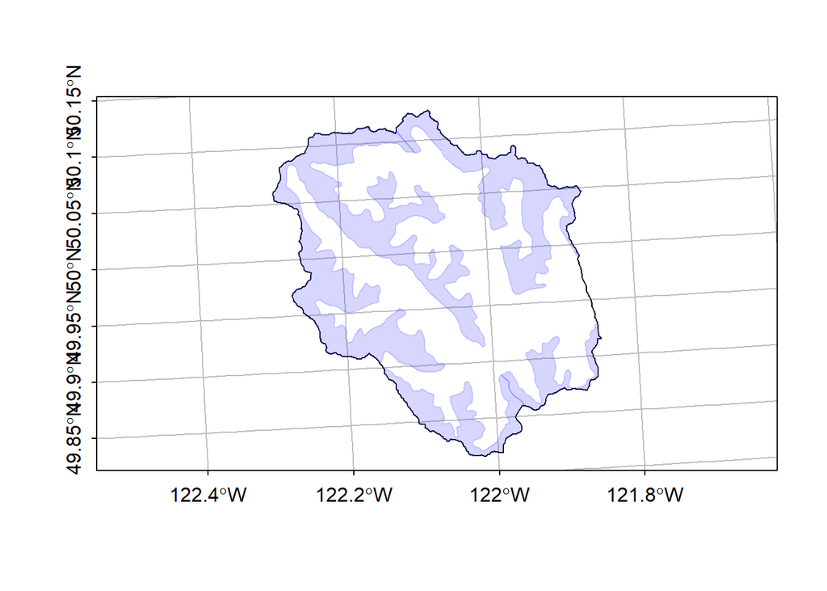

```r
nahat_sf <- frpoly_albers %>%
  dplyr::filter(Station == "08MF065")

par(tcl = -0.2, mgp = c(2, 0.5, 0))
plot(st_geometry(nahat_sf), border = "black",
     graticule = TRUE, axes = TRUE)
plot(st_geometry(wsc_alp_int), add = TRUE,
     border = my_blue, col = my_blue)
```

Compute areas within the intersected polygons and sum them within each catchment.

```r
# compute area of each intersected polygon
alpine_area <- st_area(wsc_alp_int)

# add area to sf object containing intersected polygons
wsc_alp_int$alpine_area <- alpine_area

# sum alpine areas within each catchment
wsc_alpine_areas <- wsc_alp_int %>%
  st_set_geometry(NULL) %>%
  group_by(Station) %>%
  summarize(wsc_alpine = sum(alpine_area)) %>%
  ungroup()
knitr::kable(wsc_alpine_areas)
```

| Station | wsc_alpine |
| --- | --- |
| 08JC002 | 932189117 [m^2] |
| 08KG001 | 67087712 [m^2] |
| 08KH006 | 496880289 [m^2] |
| 08ME002 | 80836456 [m^2] |
| 08MF065 | 304924117 [m^2] |
| 08LF051 | 1221574682 [m^2] |

Finally, compute the fractional coverage.

```r
# combine with wsc station info and calculate alpine fraction
wsc_alp_frac <- wsc_stns %>%
  left_join(wsc_alpine_areas, by = "Station") %>%
  mutate(wsc_alpine = ifelse(is.na(wsc_alpine), 0, wsc_alpine)) %>%
  mutate(alpine_percent = 100*round(wsc_alpine/basin_area, digits = 3)) %>%
  dplyr::select(Station, stn_name, alpine_percent)

names(wsc_alp_frac) <- c("Station", "Station name", "Alpine cover (%)")
knitr::kable(wsc_alp_frac)
```

| Station | Station name | Alpine cover (%) |
| --- | --- | --- |
| 08KC001 | SALMON RIVER NEAR PRINCE GEORGE | 0.0 |
| 08JC002 | NECHAKO RIVER AT ISLE PIERRE | 2.2 |
| 08KG001 | WEST ROAD RIVER NEAR CINEMA | 0.5 |
| 08KH006 | QUESNEL RIVER NEAR QUESNEL | 4.3 |
| 08KE016 | BAKER CREEK AT QUESNEL | 0.0 |
| 08ME002 | CAYOOSH CREEK NEAR LILLOOET | 9.1 |
| 08MF065 | NAHATLATCH RIVER BELOW TACHEWANA CREEK | 42.8 |
| 08LF051 | THOMPSON RIVER NEAR SPENCES BRIDGE | 2.2 |

# References

Government of Canada. 2019. “National Hydrometric Network Basin Polygons.” https://open.canada.ca/data/en/dataset/0c121878-ac23-46f5-95df-eb9960753375.

Trubilowicz, J., R. D. Moore, and J. M. Buttle. 2013. “Prediction of streamflow regime using ecological classification zones.” *Hydrological Processes* 27: 1935–44. https://doi.org/10.1002/hyp.9874.